# Informe técnico — Uso de medios y confianza (ESS)

Arturo

2025-08-09

# 1. Descripción breve

Este informe resume hallazgos del módulo **Media use & trust** del **European Social Survey** (ESS), a partir de la base depurada usada en el proyecto.

- Observaciones totales: **536717**
- Países: **39**
- Rondas ESS: **1, 2, 3, 4, 5, 6, 7, 8, 9, 10, 11**

Los indicadores clave utilizados son:

- `uso_internet_tiempo_min`: minutos de uso de internet en un día típico
- `tv_politica` y `lectura_politica`: tiempo en categorías (0–7) dedicado a noticias de política en TV y prensa
- `confianza_personas`: escala 0–10 (mayor = más confianza interpersonal)

> Nota: Las categorías especiales (66/77/88/99/6666/7777/8888/9999) fueron tratadas como **NA** según el codebook.

# 2. Tabla resumen (indicadores por país)

A continuación se muestra un resumen por país con promedios de los indicadores principales.  
Las columnas de TV y prensa son promedios en su **escala ordinal** (0–7).

```r
tabla_pais <- data %>%
  group_by(pais) %>%
  summarise(
    n                = n(),
    internet_min_med = mean(uso_internet_tiempo_min, na.rm = TRUE),
    tv_politica_med  = mean(tv_politica, na.rm = TRUE),
    prensa_pol_med   = mean(lectura_politica, na.rm = TRUE),
    confianza_med    = mean(confianza_personas, na.rm = TRUE)
  ) %>%
  arrange(desc(internet_min_med))

knitr::kable(
  tabla_pais,
  caption = "Resumen por país: tamaño muestral y promedios de indicadores",
  digits = 2,
  align = "lrrrrr"
) |>
  kableExtra::kable_styling(full_width = FALSE, bootstrap_options = c("striped","hover"))
```

Resumen por país: tamaño muestral y promedios de indicadores

| pais | n | internet_min_med | tv_politica_med | prensa_pol_med | confianza_med |
| --- | --- | --- | --- | --- | --- |
| IL | 17124 | 286.12 | 2.16 | 2.19 | 5.12 |
| LV | 5173 | 281.55 | 1.87 | 1.43 | 3.98 |
| CY | 6750 | 277.72 | 1.79 | 1.18 | 3.93 |
| IS | 4817 | 270.53 | 1.84 | 1.87 | 6.44 |
| ES | 21296 | 267.48 | 1.89 | 1.62 | 4.96 |
| SE | 19446 | 263.65 | 1.92 | 1.60 | 6.12 |
| NO | 17402 | 263.51 | 2.24 | 1.87 | 6.70 |
| NL | 20024 | 257.26 | 2.19 | 1.60 | 5.98 |
| EE | 16856 | 256.60 | 2.14 | 1.97 | 5.53 |
| PT | 19254 | 247.10 | 2.18 | 1.34 | 3.87 |
| GB | 22663 | 246.64 | 2.06 | 1.57 | 5.30 |
| RS | 5111 | 235.80 | NaN | NaN | 3.83 |
| DE | 36845 | 235.47 | 1.82 | 1.55 | 4.89 |
| PL | 19131 | 232.61 | 1.94 | 1.74 | 3.93 |
| DK | 12408 | 232.20 | 2.31 | 1.78 | 6.93 |
| LT | 13017 | 226.99 | 1.95 | 1.48 | 4.91 |
| RU | 12458 | 219.54 | 1.81 | 1.33 | 4.14 |
| MK | 1429 | 219.33 | NaN | NaN | 3.37 |
| BG | 15479 | 217.23 | 2.31 | 1.63 | 3.48 |
| IE | 24250 | 212.32 | 2.03 | 2.10 | 5.40 |
| GR | 15315 | 210.35 | 1.81 | 0.77 | 4.08 |
| FI | 21095 | 207.75 | 2.09 | 1.65 | 6.65 |
| HR | 8098 | 203.66 | 1.86 | 1.27 | 4.39 |
| CH | 18309 | 202.90 | 1.57 | 1.47 | 5.77 |
| FR | 20809 | 195.93 | 2.14 | 1.55 | 4.53 |
| SI | 14732 | 194.26 | 1.69 | 1.43 | 4.29 |
| ME | 4087 | 192.04 | NaN | NaN | 3.87 |
| BE | 19045 | 191.98 | 1.86 | 1.57 | 5.11 |
| CZ | 20090 | 189.61 | 1.78 | 1.41 | 4.63 |
| SK | 12734 | 186.57 | 1.88 | 1.64 | 4.02 |
| HU | 18760 | 181.96 | 1.67 | 1.62 | 4.42 |
| AT | 17579 | 180.43 | 1.70 | 1.64 | 5.24 |
| IT | 13043 | 177.22 | 2.16 | 1.11 | 4.71 |
| AL | 1201 | NaN | 2.25 | NaN | 3.01 |
| LU | 3187 | NaN | 1.86 | 1.73 | 5.11 |
| RO | 2146 | NaN | 2.62 | 1.93 | 3.79 |
| TR | 4272 | NaN | 2.33 | 1.24 | 2.60 |
| UA | 9987 | NaN | 2.02 | 1.85 | 4.20 |
| XK | 1295 | NaN | 2.32 | NaN | 3.64 |

**Comentario:** En promedio, el país con mayor uso de internet (minutos/día) es **IL** con **286.1** min/día, mientras que la **confianza interpersonal** media más alta se observa en **DK** (≈ **6.93**).

# 3. Gráfico principal

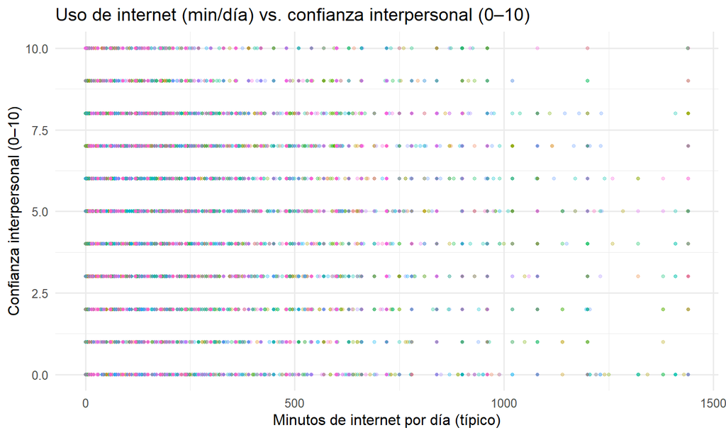

```r
ggplot(data, aes(x = uso_internet_tiempo_min, y = confianza_personas)) +
  geom_point(alpha = 0.3, size = 1, aes(color = pais)) +
  geom_smooth(method = "loess", se = TRUE, color = "black") +
  labs(
    title = "Uso de internet (min/día) vs. confianza interpersonal (0–10)",
    x = "Minutos de internet por día (típico)",
    y = "Confianza interpersonal (0–10)",
    color = "País"
  ) +
  theme_minimal(base_size = 12) +
  theme(legend.position = "none")
```

**Lectura del gráfico:** En el conjunto de países y rondas, la tendencia global es **ligeramente negativa** (correlación ≈ **-0.01**), si bien **existe heterogeneidad** por país/ronda (no mostrada aquí).

# 4. Hallazgos en relación con los objetivos

- **O1. Entender patrones de uso de medios**: La tabla muestra diferencias notables entre países en minutos de internet y consumo informativo (TV/prensa).
- **O2. Describir variaciones en confianza interpersonal**: La media de confianza varía entre países; p.ej., el valor más alto observado es ≈ **6.93**.
- **O3. Explorar relación medios–confianza**: La relación global **no apoya una relación positiva clara** entre uso de internet y confianza, pero **debe analizarse por país/ronda**.

# 5. Conclusiones y próximos pasos

- Los **promedios por país** son útiles para comunicar resultados de alto nivel; sin embargo, conviene complementar con **modelos multivariantes** (p. ej., efectos por país y ronda, y controles demográficos si están disponibles en otra tabla del ESS).
- Para mejorar el storytelling, se pueden añadir **gráficos por país** (pequeños múltiples) o un **dashboard** (ya desarrollado en el repo) para exploración interactiva.